cviko 2

rozdelenia prevdepodobnosti, diskretne a spojite

zakladne prikazy

d -> ak p(x=i)=p_i

p -> ak p(x<=i)

q -> pre kvanil

r -> random

binomicke rozdelenie

- n => pocet pokusov nezavislych
- p => pravdepodobnost 1 pokusu

priklad ucinost antibiotik je 80% podava sa 10 pacientom zratajte pravdepodobnosti:

- vseci sa vyliecia p=(x=10)
- 7 sa vylieci p=(x=7)
- najviac 8 p=(x<=8)
- aspon 5 p=(x>=5)

```r
dbinom(10,10,0.8)
```

```
## [1] 0.1073742
```

```r
dbinom(7,10,0.8)
```

```
## [1] 0.2013266
```

```r
pbinom(8,10,0.8)
```

```
## [1] 0.6241904
```

```r
1-pbinom(4,10,0.8)
```

```
## [1] 0.9936306
```

```r
pbinom(4,10,0.8,lower.tail = FALSE)
```

```
## [1] 0.9936306
```

uloha: dabulka rozdelenia pravdepodobnosti a graf rozdelenia pravdepodobnosti

```r
xB <- c(0:10)
hustotaB <- dbinom(xB,10,0.8)
tabulkaB <- data.frame(hodnota=xB,pravdepodobnost=hustotaB)
tabulkaB
```

```
##    hodnota pravdepodobnost
## 1        0    0.0000001024
## 2        1    0.0000040960
## 3        2    0.0000737280
## 4        3    0.0007864320
## 5        4    0.0055050240
## 6        5    0.0264241152
## 7        6    0.0880803840
## 8        7    0.2013265920
## 9        8    0.3019898880
## 10       9    0.2684354560
## 11      10    0.1073741824
```

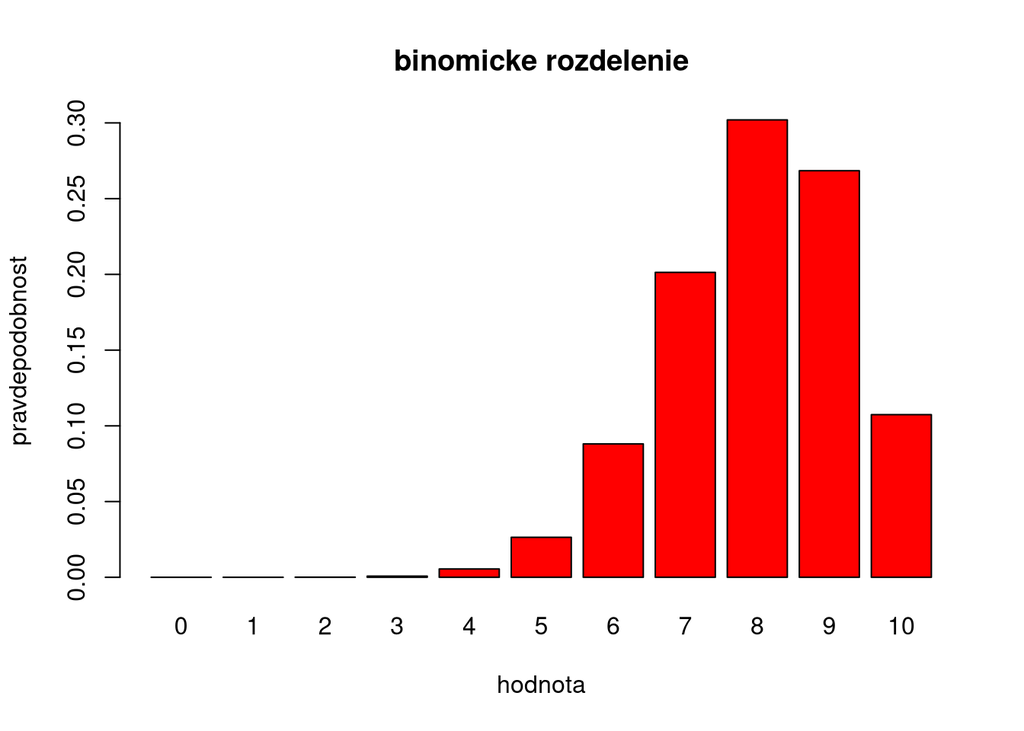

```r
barplot(tabulkaB$pravdepodobnost, main = "binomicke rozdelenie",xlab = "hodnota", ylab = "pravdepodobnost", col = "red", names.arg = xB)
```

hypergeometricke rozdelenie ma tri parametre

m - pocet objektov s sledovanov vlastnostou n - doplnok m k - kolko vyberam

priklad student sa nauci na skusku 12 z 20 otazok test obsahuje 5 z 20 vypocitajte pravdepodobnosti:

- student spravi skusku (aspon 3 otazky)
- student dostane A (5 otazok zodpovie)
- student nespravi skusku (menej ako 3)

```r
phyper(2,12,8,5, lower.tail = F) # x<2
```

```
## [1] 0.7038184
```

```r
dhyper(5,12,8,5)
```

```
## [1] 0.05108359
```

```r
phyper(2,12,8,5)
```

```
## [1] 0.2961816
```

```r
xB <- c(0:5)
hustotaB <- dhyper(xB,12,8,5)
tabulkaB <- data.frame(hodnota=xB,pravdepodobnost=hustotaB)
tabulkaB
```

```
##   hodnota pravdepodobnost
## 1       0     0.003611971
## 2       1     0.054179567
## 3       2     0.238390093
## 4       3     0.397316821
## 5       4     0.255417957
## 6       5     0.051083591
```

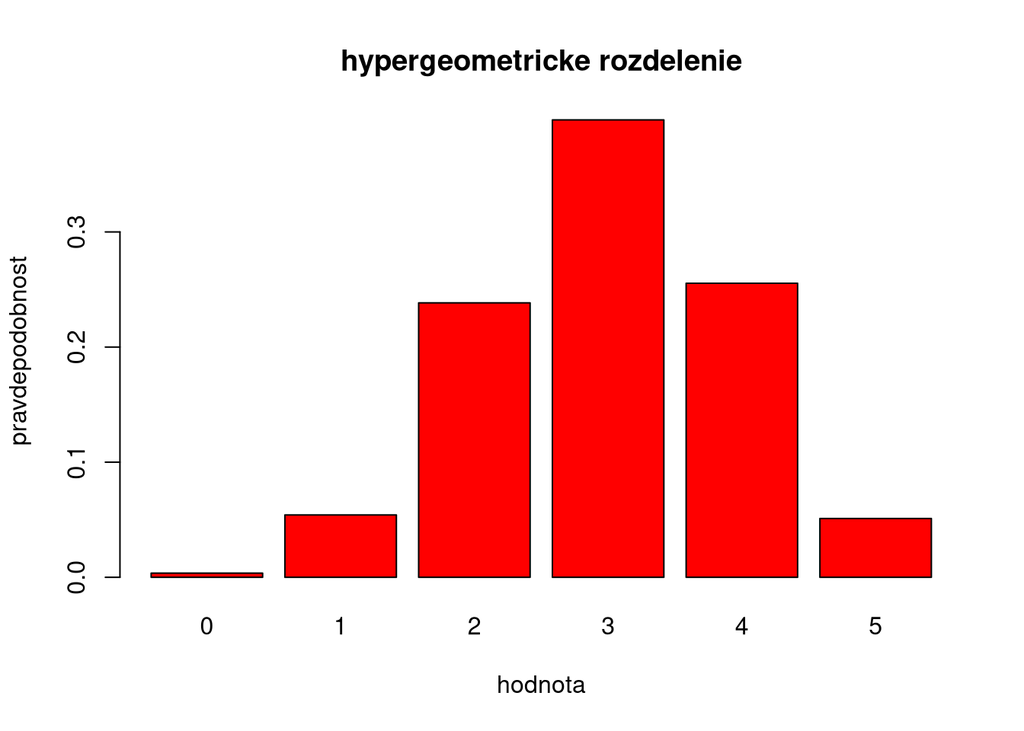

```r
barplot(tabulkaB$pravdepodobnost, main = "hypergeometricke rozdelenie",xlab = "hodnota", ylab = "pravdepodobnost", col = "red", names.arg = xB)
```

# Poissonovo rozdelenie

parameter lambda co je stredna hodnota

teoria hromadnej obsluhy, zriedkave javy

priklad - na samoobsluznej linke je 20 ludi / hod

vypocitajte - pravdepodobnost ze za 15 min pride 1 clovek - 20/60 * 15 - ze za 5 min nikto nepride - 20/60 * 5 - ze za 10 min aspon 10 ludi - 20/60 * 10

lambda sa prepocita vzhladom na casovy interval

```r
dpois(1,5)
```

```
## [1] 0.03368973
```

```r
dpois(0,5/3)
```

```
## [1] 0.1888756
```

```r
ppois(9,10/3,lower.tail = F)
```

```
## [1] 0.002356375
```

vypocitame tabulku a grav rozdelenia pravdepodobnosti pre lambda = 20

```r
xP <- c(0:20)
hustotaB <- dpois(xP, 20)
tabulkaB <- data.frame(hodnota=xP, pravdepodobnost=hustotaB)
tabulkaB
```

```
##    hodnota pravdepodobnost
## 1        0    2.061154e-09
## 2        1    4.122307e-08
## 3        2    4.122307e-07
## 4        3    2.748205e-06
## 5        4    1.374102e-05
## 6        5    5.496410e-05
## 7        6    1.832137e-04
## 8        7    5.234676e-04
## 9        8    1.308669e-03
## 10       9    2.908153e-03
## 11      10    5.816307e-03
## 12      11    1.057510e-02
## 13      12    1.762517e-02
## 14      13    2.711565e-02
## 15      14    3.873664e-02
## 16      15    5.164885e-02
## 17      16    6.456107e-02
## 18      17    7.595420e-02
## 19      18    8.439355e-02
## 20      19    8.883532e-02
## 21      20    8.883532e-02
```

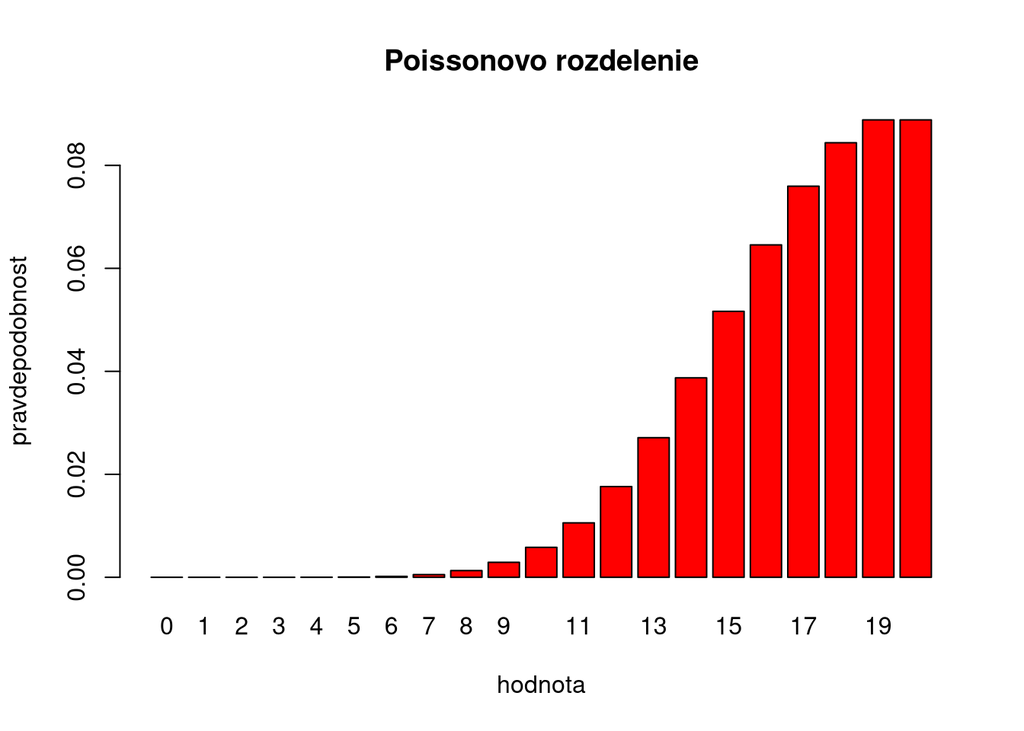

```r
barplot(tabulkaB$pravdepodobnost, main = "Poissonovo rozdelenie",xlab = "hodnota", ylab = "pravdepodobnost", col = "red", names.arg = xP)
```

zostrojte epiricku distribucnu funkciu pre 10 000 pseudonah cisiel

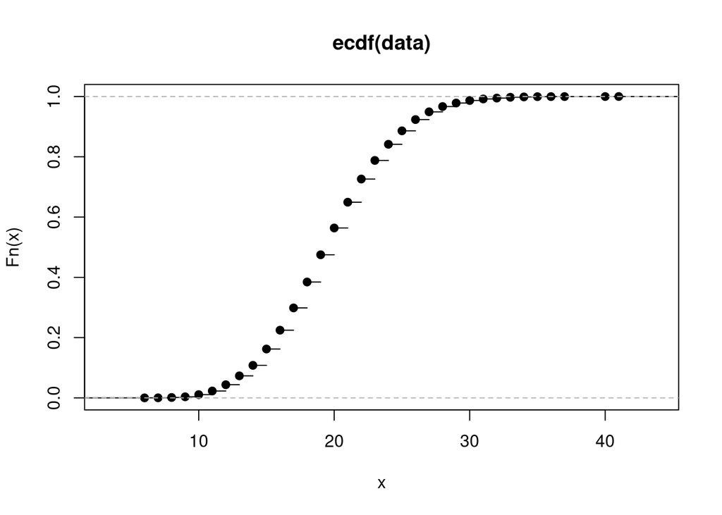

```r
data <- rpois(10000, 20)
plot(ecdf(data))
```

# spojite rozdelenie pravepodobnosti

odbor hodnot je interval

rozdelenie pravdepodobnosti je dane hustotov pravdepodobnosti

# normalne rozdelenie

normalne - gaussovo parameter: - mi - stredna hodnota - sigma - smerodajna odchylka

prikad: zivotnost bateriek do mobilu sa riadi rozdelenim so strednou hodnotou 8 rokov odchylkov 2 roky

vypocitaj kolko % bateriek treba vymenit za 7,5 roka kolko % bateriek vydrzi 7-9 rokov kolko % viac ako 10 rokov na aku dobu zivotnosti sa mozeme zarucit na 90%

```r
pnorm(7.5, 8,2)
```

```
## [1] 0.4012937
```

```r
pnorm(9,8,2) - pnorm(7,8,2)
```

```
## [1] 0.3829249
```

```r
pnorm(10,8,2,lower.tail = F)
```

```
## [1] 0.1586553
```

```r
qnorm(0.1, 8,2)
```

```
## [1] 5.436897
```

```r
qnorm(0.9, 8,2,lower.tail = F)
```

```
## [1] 5.436897
```

histogram a hustota normalneho N(0,1)

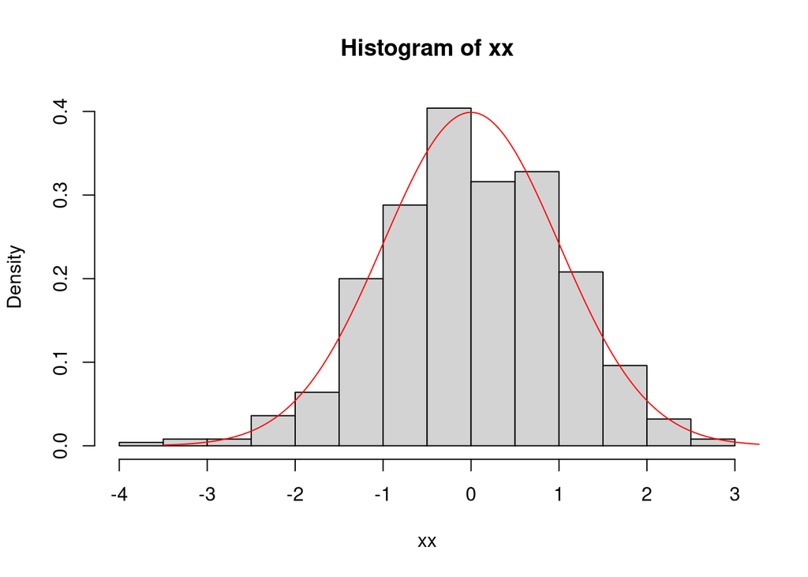

```r
xx <- rnorm(500,0,1) # pre histogram
xxx <- seq(-3.5, 3.5,0.01)
hist(xx, freq = F)
lines(xxx,dnorm(xxx,0,1), col = "red")
```

# exponencialne rozdelenie

jden parameter E(x) dlzka zivotnosti pouzivaneho pc v pocitacovej ucebni je 2 roky

aka je pravepodobnost ze pc ma zivotnost aspon 1 rok najviac 5 rokov za aku zivotnost by ste sa zarucil len s p = 0,05

```r
pexp(1,1/2,lower.tail = F)
```

```
## [1] 0.6065307
```

```r
pexp(5,1/2)
```

```
## [1] 0.917915
```

```r
qexp(0.05,1/2, lower.tail = F)
```

```
## [1] 5.991465
```

# hustota

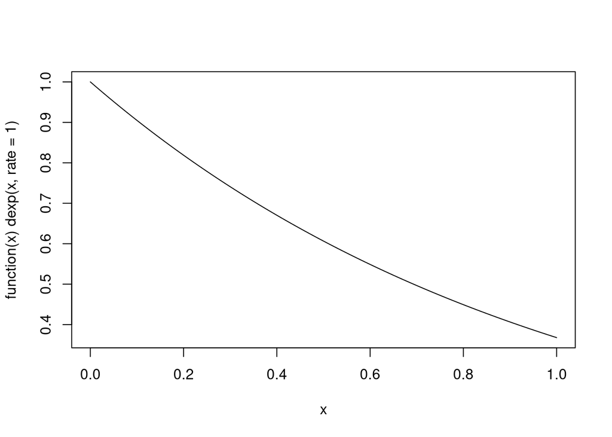

```r
x <- 0:5
plot(function (x)dexp(x,rate = 1))
```